# HTG_vignette

# DETAILED TUTURAL

This is a detailed tutorial to guide you through the usage of the ‘HTGAnalyzer’ package. The first step is to load the library:

[output not shown]

## HTG technology:

### HTG_auto() for HTG:

We will start explaining the function `HTG_auto`. This function was designed to simplify the process of performing multiple analyses on HTG data. It has a lot of variables that can be turned on and off to skip an analysis if you wanted or also the function has a lot of variables in case you want to change the stablished threshold that we propose.

You can download the example Excel files from the following link: https://github.com/ISGLOBAL-Rakislova-Lab/HTGAnalyzer/tree/main/SUPLEMENTARY_OUTPUT

#### HTG_auto(): All the analysis for HTG:

Imagine you have HTG data and want to perform a comprehensive set of analyses, including Differential Expression Analysis (DEA), Tumor Microenvironment (TME) analysis, Survival Analysis, and Gene Set Enrichment Analysis (GSEA).

The code below demonstrates how to conduct each of these analyses. We’ve highlighted all the variables that can be modified in the functions, just to make you aware of them, but feel free to leave them unchanged if they suit your needs.

```r
result <- HTG_auto(
  counts_file_path = "~/HTGAnalyzer/counts.xlsx",
  file_type = "HTG",
  AnnotData_file_path = "~/HTGAnalyzer/annotdata.xlsx",
  pattern = "^NC-|^POS-|^GDNA-|^ERCC-",
  threshold_superior_pos = 5,
  threshold_line_pos = 4,
  threshold_inferior_lib = 5e+06,
  threshold_lib = 7e+06,
  threshold_superior_nc = 0.05,
  threshold_line_nc = 0.045,
  threshold_superior_gdna = 0.025,
  threshold_line_gdna = 0.02,
  threshold_superior_ercc = 0.03,
  threshold_line_ercc = 0.025,
  threshold_inferior_median = 3,
  threshold_line_median = 5,
  save_csv = TRUE,
  csv_file = "QC_results.csv",
  design_formula = "HPV_status",
  percentage_gene = 0.2,
  threshold_gene = 200,
  threshold_subject = 10,
  genes_to_use = c("CCND1", "MMP10", "CTTN"),
  heatmap_columns = c("HPV_status", "Ciclina_D1"),
  contrast = c("HPV_status", "Associated", "Independent"),
  pCutoff = 5e-2,
  variable_01 = "Recurrence_01",
  time = "Time_to_death_surv",
  DEA = TRUE,
  remove_outliers = TRUE,
  GSEA = TRUE,
  generate_heatmap = TRUE,
  TME = TRUE,
  survival_analysis = TRUE
)
```

The code above is an example. Some of the parameters have default values in the function, but they are included here for clarity. Refer to the function documentation for more details on each parameter.

#### HTG_auto(): skipping an analysis for HTG:

If you want to perform some analyses but exclude others (e.g., skipping survival analysis and GSEA), you can set the relevant parameter to FALSE. Below is an example where survival and GSEA analyses are excluded:

If an analysis requires a specific column that you don’t have (e.g., survival analysis needs the variable_01 and time columns), you can set those variables to NULL to skip that particular analysis.

```r
## LET'S SKIP survival analysis and GSEA

result <- HTG_auto(
  counts_file_path = "~/HTGAnalyzer/counts.xlsx",  # Path to counts data
  file_type = "HTG",  # Type of file
  AnnotData_file_path = "~/HTGAnalyzer/annotdata.xlsx",  # Path to annotation data
  pattern = "^NC-|^POS-|^GDNA-|^ERCC-",  # HTG probes that start with one of these prefixes
  # These thresholds are specific for the HTG transcriptomic panel
  threshold_superior_pos = 5,
  threshold_line_pos = 4,
  threshold_inferior_lib = 5e+06,
  threshold_lib = 7e+06,
  threshold_superior_nc = 0.05,
  threshold_line_nc = 0.045,
  threshold_superior_gdna = 0.025,
  threshold_line_gdna = 0.02,
  threshold_superior_ercc = 0.03,
  threshold_line_ercc = 0.025,
  threshold_inferior_median = 3,
  threshold_line_median = 5,
  save_csv = TRUE,
  csv_file = "QC_results.csv",
  design_formula = "HPV_status",
  percentage_gene = 0.2,
  threshold_gene = 200,
  threshold_subject = 10,
  genes_to_use = c("CCND1", "MMP10", "CTTN"),  # Genes used for survival analysis (optional)
  heatmap_columns = c("HPV_status", "Ciclina_D1"),
  contrast = c("HPV_status", "Associated", "Independent"),  # Contrast for differential analysis
  pCutoff = 5e-2,
  variable_01 = "Recurrence_01",  # Variable for survival analysis
  time = "Time_to_death_surv",  # Time for survival analysis
  DEA = TRUE,
  remove_outliers = TRUE,
  GSEA = FALSE,
  generate_heatmap = TRUE,
  TME = TRUE,
  survival_analysis = FALSE  # Skip survival analysis by setting this parameter to FALSE
)
```

In this example, survival analysis is skipped by setting `survival_analysis = FALSE`and GSA by setting `GSEA = FALSE`. The output will indicate that the survival analysis step has been skipped.

### STEP BY STEP for HTG:

What if you already had some analysis or you want to get more control over it? Don’t worry we have the solution.Let’s go `step-by-step`, starting with data import:

#### Load data: HTG_import_counts() for HTG:

You can upload data directly from HTG Edge Reveal using this format. R needs a quadratic information structure, so maybe you will have to edit your data to look like this on excel before importing:

| **id** | patient_1 | patient_2 | patient_3 | patient_4 | patient_5 | patient_6 | patient_7 | patient_8 |
| --- | --- | --- | --- | --- | --- | --- | --- | --- |
| **Sample ID** | 1 | 2 | 3 | 4 | 5 | 6 | 7 | 8 |
| **Well** | A1 | B1 | C1 | D1 | E1 | F1 | G1 | H1 |
| **Date Parsed** | 14/08/2024 | 14/08/2024 | 14/08/2024 | 14/08/2024 | 14/08/2024 | 14/08/2024 | 14/08/2024 | 14/08/2024 |
| **Total Counts** | 9650628 | 33950226 | 24680689 | 10605963 | 7395173 | 4057094 | 20049502 | 13607678 |
| **A3GALT2** | 0 | 0 | 164 | 19 | 46 | 1 | 0 | 0 |
| **A4GALT** | 2 | 662 | 665 | 830 | 748 | 89 | 256 | 333 |
| **A4GNT** | 0 | 1041 | 103 | 0 | 0 | 2 | 0 | 0 |
| **AAAS** | 0 | 368 | 70 | 634 | 707 | 425 | 587 | 872 |
| **AACS** | 1 | 0 | 562 | 728 | 250 | 209 | 365 | 445 |
| **AADAC** | 0 | 382 | 0 | 5 | 144 | 0 | 0 | 1 |

Or an alternative format:

| **id** | patient_10 | patient_11 | patient_5 | patient_6 | patient_4 | patient_1 | patient_2 | patient_3 | patient_7 | patient_9 | patient_8 |
| --- | --- | --- | --- | --- | --- | --- | --- | --- | --- | --- | --- |
| **A3GALT2** | 0 | 0 | 164 | 19 | 46 | 1 | 0 | 0 | 0 | 0 | 0 |
| **A4GALT** | 2 | 662 | 665 | 830 | 748 | 89 | 256 | 333 | 210 | 2 | 504 |
| **A4GNT** | 0 | 1041 | 103 | 0 | 0 | 2 | 0 | 0 | 84 | 0 | 0 |
| **AAAS** | 0 | 368 | 70 | 634 | 707 | 425 | 587 | 872 | 542 | 0 | 370 |
| **AACS** | 1 | 0 | 562 | 728 | 250 | 209 | 365 | 445 | 62 | 46 | 785 |
| **AADAC** | 0 | 382 | 0 | 5 | 144 | 0 | 0 | 1 | 260 | 683 | 77 |

```r
## LOAD COUNTS DATA

htg_data <- HTG_import_counts("~/HTGAnalyzer/counts.xlsx", "HTG")
head(htg_data)

## LOAD ANNOTDATA
annotdata<- readxl::read_excel("~/HTGAnalyzer/annotdata.xlsx")
head(annotdata)
```

**NOTE:** For the following functions, we’ll use tutorial data from the package. If you want to try with your data, replace `counts_data_tutorial` with `htg_data`.

#### HTG_quant_to_qual() for HTG:

If you need to transform a quantitative column to a qualitative one, you can use this function.

```r
head(AnnotData_tutorial)
```

```
#>                  id  HPV_status Ciclina_D1 FIGO_2021_STAGE Recurrence
#> patient_1 patient_1  Associated         10            IIIB        yes
#> patient_2 patient_2  Associated         50              II         no
#> patient_3 patient_3  Associated         NA            IIIC         no
#> patient_4 patient_4  Associated          0              IB        yes
#> patient_5 patient_5 Independent         50              IB        yes
#> patient_6 patient_6 Independent         80              IB         no
#>           Recurrence_01 Time_to_death_surv Ciclina_D12
#> patient_1             1               1287         low
#> patient_2             0                510         low
#> patient_3             0                762        <NA>
#> patient_4             1               1164         low
#> patient_5             1               5844         low
#> patient_6             0               1436        high
```

```r
AnnotData_tutorial <- HTG_quant_to_qual(AnnotData_tutorial,  # Dataset to modify
                                        "Ciclina_D1",  # Column to transform
                                        60,  # Threshold to categorize the data
                                        "high",  # Value for entries greater than 60
                                        "low")  # Value for entries less than 60
#Last column will be the generated one
head(AnnotData_tutorial)
```

```
#>                  id  HPV_status Ciclina_D1 FIGO_2021_STAGE Recurrence
#> patient_1 patient_1  Associated         10            IIIB        yes
#> patient_2 patient_2  Associated         50              II         no
#> patient_3 patient_3  Associated         NA            IIIC         no
#> patient_4 patient_4  Associated          0              IB        yes
#> patient_5 patient_5 Independent         50              IB        yes
#> patient_6 patient_6 Independent         80              IB         no
#>           Recurrence_01 Time_to_death_surv Ciclina_D12
#> patient_1             1               1287         low
#> patient_2             0                510         low
#> patient_3             0                762        <NA>
#> patient_4             1               1164         low
#> patient_5             1               5844         low
#> patient_6             0               1436        high
```

```r
head(AnnotData_tutorial$Ciclina_D12)
```

```
#> [1] "low"  "low"  NA     "low"  "low"  "high"
```

#### HTG_subset() for HTG:

Now that you have the counts data loaded, you can search for certain genes of interest, look for specific probes, or filter results from DEA. This function can also normalize the data by TPM (Transcripts Per Million).

```r
# Subset rows with the prefix "ERCC"
cts_ERCC <- HTG_subset(counts_data_tutorial, "ERCC")
```

```
#> Subsetting without normalization...
#> Dimensions: 101 11
```

```r
# Subset rows with the prefix "POS"
cts_POS <- HTG_subset(counts_data_tutorial, "POS")
```

```
#> Subsetting without normalization...
#> Dimensions: 5 11
```

```r
 # Subset rows with the prefix "NC"
cts_NC <- HTG_subset(counts_data_tutorial, "NC")
```

```
#> Subsetting without normalization...
#> Dimensions: 146 11
```

```r
# Subset rows with the prefix "GDNA"
cts_GDNA <- HTG_subset(counts_data_tutorial, "GDNA")
```

```
#> Subsetting without normalization...
#> Dimensions: 22 11
```

```r
# Subset rows with the prefix "ZZZ3"
cts_ZZZ3 <- HTG_subset(counts_data_tutorial, "ZZZ3")
```

```
#> Subsetting without normalization...
#> Dimensions: 1 11
```

```r
# Subset rows with the prefix "ZZZ3" and normalize the data
cts_ZZZ3 <- HTG_subset(counts_data_tutorial, "ZZZ3", normalize = TRUE)
```

```
#> Normalizing data using TPM (Transcripts Per Million)...
#> Dimensions: 1 11
```

```r
resAAAS<- HTG_subset(res_tutorial, "AAAS")
```

```
#> Subsetting without normalization...
#> Dimensions: 1 6
```

#### Perform a QC: HTG_QC() for HTG:

Now, let’s perform quality control (QC) on the tutorial data. As you may know, HTG uses specific probes to perform QC to detect outliers and assess data quality. Default thresholds are provided, but feel free to adjust them. This function will:

1. Detect outliers and save them in an object called `outliers`.
2. Generate visualization plots.
3. Perform summary statistics and save them in a .csv file.
4. Generate a table with the QC results for further review.

```r
outliers <- HTG_QC(counts_data_tutorial, pattern = "^NC-|^POS-|^GDNA-|^ERCC-",
                             threshold_superior_pos = 5,
                             threshold_line_pos = 4,
                             threshold_inferior_lib = 5e+06,
                             threshold_lib = 7e+06,
                             threshold_superior_nc = 0.05,
                             threshold_line_nc = 0.045,
                             threshold_superior_gdna = 0.025,
                             threshold_line_gdna = 0.02,
                             threshold_superior_ercc = 0.03,
                             threshold_line_ercc = 0.025,
                             threshold_inferior_median = 3,
                             threshold_line_median = 5,
                             save_csv = TRUE,
                             csv_file = "QC_results.csv")
```

```
#> INITIATING DATA FILTERING...
#> Summary statistics saved as 'summary_stats.csv'
#> INITIATING QC PLOTS...
#>            ID total_POS total_NC total_GDNA total_ERCC    pos/gens   Q0
#> 1   patient_1     80307      696        172        256  0.64028783 PASS
#> 2   patient_2      6381       29         37         15  0.04489742 PASS
#> 3   patient_3      4418        9         24         11  0.02725260 PASS
#> 4   patient_4     68866     3034        884       1355  0.51098424 PASS
#> 5   patient_5    214604     2738       1598       1523  1.75876807 PASS
#> 6   patient_6     31934      393        146        236  0.24849258 PASS
#> 7   patient_7     88459     1760        844       1247  0.65164132 PASS
#> 8   patient_8    168625      695        413       1001  1.25664410 PASS
#> 9   patient_9    910985     1714       7202        103  7.73949173 FAIL
#> 10 patient_10   3347486    13712       2372       3580 31.62646098 FAIL
#> 11 patient_11     32239      274      17785        186  0.22045428 PASS
#>    total_gens   Q1      nc/gens   Q2    gdna/gens   Q3    ERCC/gens   Q4 median
#> 1    12542328 PASS 5.549209e-03 PASS 0.0013713563 PASS 2.041088e-03 PASS     69
#> 2    14212399 PASS 2.040472e-04 PASS 0.0002603361 PASS 1.055416e-04 PASS    139
#> 3    16211297 PASS 5.551684e-05 PASS 0.0001480449 PASS 6.785392e-05 PASS    189
#> 4    13477128 PASS 2.251221e-02 PASS 0.0065592610 PASS 1.005407e-02 PASS    167
#> 5    12201950 PASS 2.243904e-02 PASS 0.0130962674 PASS 1.248161e-02 PASS    131
#> 6    12851088 PASS 3.058107e-03 PASS 0.0011360906 PASS 1.836420e-03 PASS    126
#> 7    13574799 PASS 1.296520e-02 PASS 0.0062174033 PASS 9.186140e-03 PASS     73
#> 8    13418676 PASS 5.179349e-03 PASS 0.0030777999 PASS 7.459752e-03 PASS     96
#> 9    11770605 PASS 1.456170e-02 PASS 0.0611863196 FAIL 8.750612e-04 PASS      0
#> 10   10584447 PASS 1.295486e-01 PASS 0.0224102402 FAIL 3.382321e-02 FAIL      0
#> 11   14623894 PASS 1.873646e-03 PASS 0.1216160347 FAIL 1.271891e-03 PASS    503
#>      Q5 min     max     mean QC_status
#> 1  PASS   0  461925 646.7118      PASS
#> 2  PASS   0  162327 732.8245      PASS
#> 3  PASS   0  189344 835.8924      PASS
#> 4  PASS   0  225483 694.9122      PASS
#> 5  PASS   0  285334 629.1611      PASS
#> 6  PASS   0  264344 662.6322      PASS
#> 7  PASS   0  658315 699.9484      PASS
#> 8  PASS   0  278813 691.8983      PASS
#> 9  FAIL   0 2325356 606.9199      FAIL
#> 10 FAIL   0 1638654 545.7588      FAIL
#> 11 PASS   0 1527692 754.0422      FAIL
#> QC DATA SAVED AS ' QC_results.csv '
```

[output cut: 25 more lines]

```
#>  (Other)   :86960
#>    Threshold
#>  Min.   :3.938
#>  1st Qu.:4.555
#>  Median :4.697
#>  Mean   :4.694
#>  3rd Qu.:4.878
#>  Max.   :5.432
#>
#> Violin plot saved as 'QC_plots_violin_plot.pdf'
#> QC plots saved as 'plot_QC.pdf'
#> Heatmap PLOTS SAVED AS 'HTG_QC_heatmap.pdf'
#>                               ***
#> These are the samples plotted at least once in the heatmap:
#> The number of samples that are outliers are: 3patient_10 patient_11 patient_9
```

#### HTG_calculate_summary_stats() for HTG:

If you only want to perform the summary statistics without full QC, this function will generate summary stats and save them in a .csv file as well as an R object.

```r
summary <- HTG_calculate_summary_stats(counts_data_tutorial, pattern = "^NC-|^POS-|^GDNA-|^ERCC-")
```

#### Perform all the analysis: HTG_analysis() for HTG:

Now that you know which samples are outliers, you can perform any of the analyses. This function will remove the outliers, perform DEA, TME, survival analysis, and GSEA. If you want to perform each step separately, you can use the functions `HTG_GSEA()`, `HTG_DEA()`, `HTG_TME()`, and `HTG_survival()`. Running the analyses individually offers greater control, allowing you to adjust additional parameters. Refer to each function’s section for detailed instructions on how they work.

```r
ALL_done <- HTG_analysis(outliers = outliers_tutorial,
                         pattern = "^NC-|^POS-|^GDNA-|^ERCC-",
                         counts_data = counts_data_tutorial,
                         col_data = AnnotData_tutorial,
                         design_formula = "HPV_status",
                         percentage_gene = 0.2,
                         threshold_gene = 200,
                         threshold_subject = 10,
                         genes_to_use = c("CCND1", "MMP10", "CTTN"),
                         heatmap_columns = c("HPV_status","Ciclina_D1"),
                         contrast = c("HPV_status", "Associated", "Independent"),
                         pCutoff = 5e-2,
                         variable_01 = "Recurrence_01",
                         time = "Time_to_death_surv",
                         DEA = TRUE,
                         remove_outliers = TRUE,
                         GSEA = FALSE,
                         generate_heatmap = TRUE,
                         TME = TRUE,
                         survival_analysis = FALSE)
```

```
#> FILTERING THE COUNT DATA. DELETING THE PROVES...
#> REMOVING OUTLIERS...
#> STARTING THE DIFERENTIAN EXPRESSION ANALYSIS.
#> [1] "HPV_status"
#>
#> BEFORE FILTERING
#> class: DESeqDataSet
#> dim: 19394 8
#> metadata(1): version
#> assays(1): counts
#> rownames(19394): A3GALT2 A4GALT ... ZZEF1 ZZZ3
#> rowData names(0):
#> colnames(8): patient_1 patient_2 ... patient_7 patient_8
#> colData names(8): id HPV_status ... Time_to_death_surv Ciclina_D12
#>
#>
#> AFTER FILTERING
#> class: DESeqDataSet
#> dim: 10293 8
#> metadata(1): version
#> assays(1): counts
#> rownames(10293): A4GALT AAAS ... ZZEF1 ZZZ3
#> rowData names(0):
#> colnames(8): patient_1 patient_2 ... patient_7 patient_8
#> colData names(8): id HPV_status ... Time_to_death_surv Ciclina_D12
#>
#> RESULTS OF VST NORMALIZATION
#> class: DESeqTransform
#> dim: 10293 8
#> metadata(1): version
#> assays(1): ''
#> rownames(10293): A4GALT AAAS ... ZZEF1 ZZZ3
#> rowData names(4): baseMean baseVar allZero dispFit
#> colnames(8): patient_1 patient_2 ... patient_7 patient_8
#> colData names(9): id HPV_status ... Ciclina_D12 sizeFactor
#>
#> HEATMAP
#> GENERATING HEATMAP
#> GENERATING CONTRAST RESULTS
#> SUMMARY OF RESULT OF THE CONTRAST
```

[output cut: 139 more lines]

```
#>    <chr>                            <chr>    <dbl>
#>  1 Myeloid_dendritic_cell_activated t-test  0.198
#>  2 B_cell                           t-test  0.0484
#>  3 T_cell_CD4+_memory               t-test  0.220
#>  4 T_cell_CD4+_naive                t-test  0.185
#>  5 T_cell_CD4+_(non-regulatory)     t-test  0.391
#>  6 T_cell_CD4+_central_memory       t-test  0.776
#>  7 T_cell_CD4+_effector_memory      t-test  0.182
#>  8 T_cell_CD8+_naive                t-test  0.171
#>  9 T_cell_CD8+                      t-test  0.0164
#> 10 T_cell_CD8+_central_memory       t-test  0.0146
#> # ℹ 29 more rows
#> GENERATING HEATMAPS
#> Heatmap of qti, EPIC and xcell will be stored on plots_TME_heatmap.pdf
#> Skipping survival analysis.
```

#### Differentia expression analysis: HTG_DEA() for HTG:

If you want more control, such as applying extra filtering or performing LFC shrinkage, `HTG_DEA()` will provide more options.

```
#> INITIATING DATA FILTERING...
#> REMOVING SPECIFIED OUTLIERS...
#> PREPARING DATA FOR DESeq2 ANALYSIS...
#> CREATING DESeqDataSet OBJECT...
#> APPLYING GENE FILTERING BASED ON THRESHOLDS...
#> PERFORMING DESeq2 ANALYSIS...
#> Results saved as 'results_HTG_DEA.csv'
#> Displaying top 10 differential expression results...
#> log2 fold change (MLE): HPV_status Associated vs Independent
#> Wald test p-value: HPV_status Associated vs Independent
#> DataFrame with 10 rows and 6 columns
#>          baseMean log2FoldChange     lfcSE      stat      pvalue        padj
#>         <numeric>      <numeric> <numeric> <numeric>   <numeric>   <numeric>
#> LCP1     4433.349        3.22176  0.331278   9.72524 2.35348e-22 2.07483e-18
#> HLA-DMB  1781.568        2.64005  0.282567   9.34312 9.35407e-21 4.12328e-17
#> LYPD3    2294.363       -7.58069  0.944092  -8.02962 9.77771e-16 2.87334e-12
#> SLAMF7   1706.337        2.63203  0.371327   7.08817 1.35898e-12 2.99520e-09
#> OMA1      606.110        2.20549  0.316706   6.96385 3.31100e-12 5.83796e-09
#> VOPP1    1296.988        2.83390  0.408990   6.92901 4.23781e-12 6.22676e-09
#> COL5A3    550.436       -3.18286  0.467776  -6.80423 1.01589e-11 1.27944e-08
#> MMP10    1804.866      -10.42896  1.593830  -6.54333 6.01644e-11 6.63012e-08
#> CDCA4     676.770       -2.44454  0.379031  -6.44945 1.12255e-10 1.09960e-07
#> TACSTD2  1909.633       -8.54117  1.332003  -6.41228 1.43360e-10 1.26386e-07
#> APPLYING LOG-FOLD CHANGE SHRINKAGE...
#> using 'apeglm' for LFC shrinkage. If used in published research, please cite:
#>     Zhu, A., Ibrahim, J.G., Love, M.I. (2018) Heavy-tailed prior distributions for
#>     sequence count data: removing the noise and preserving large differences.
#>     Bioinformatics. https://doi.org/10.1093/bioinformatics/bty895
#> log2 fold change (MAP): HPV status Independent vs Associated
#> Wald test p-value: HPV status Independent vs Associated
#> DataFrame with 10 rows and 5 columns
#>          baseMean log2FoldChange     lfcSE      pvalue        padj
#>         <numeric>      <numeric> <numeric>   <numeric>   <numeric>
#> LCP1     4433.349       -3.14866  0.334146 2.35348e-22 2.07483e-18
#> HLA-DMB  1781.568       -2.58470  0.285422 9.35407e-21 4.12328e-17
#> LYPD3    2294.363        7.34425  0.961843 9.77771e-16 2.87334e-12
#> SLAMF7   1706.337       -2.52504  0.377241 1.35898e-12 2.99520e-09
#> OMA1      606.110       -2.12104  0.321592 3.31100e-12 5.83796e-09
#> VOPP1    1296.988       -2.71818  0.416609 4.23781e-12 6.22676e-09
#> COL5A3    550.436        3.04905  0.477775 1.01589e-11 1.27944e-08
#> MMP10    1804.866        9.93535  1.640901 6.01644e-11 6.63012e-08
#> CDCA4     676.770        2.33824  0.386402 1.12255e-10 1.09960e-07
#> TACSTD2  1909.633        8.11419  1.378398 1.43360e-10 1.26386e-07
#> Saving plots as 'DEA_plots.pdf'
```

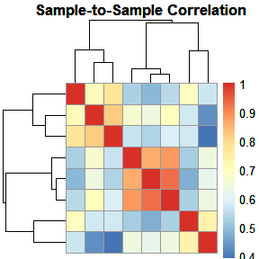

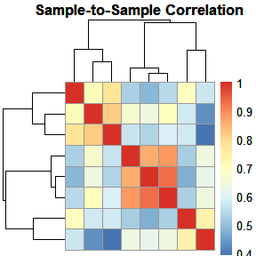

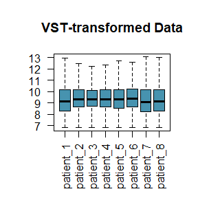

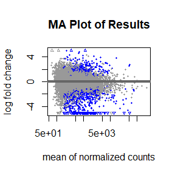

```
#> NULL
#> Plotting gene expression for gene: LCP1
```

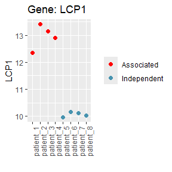

```
#> Plotting gene expression for gene: HLA-DMB
```

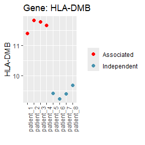

```
#> Plotting gene expression for gene: LYPD3
```

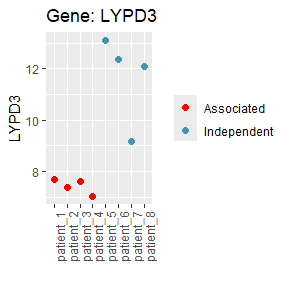

```
#> Plotting gene expression for gene: SLAMF7
```

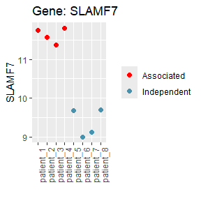

```
#> Plotting gene expression for gene: OMA1
```

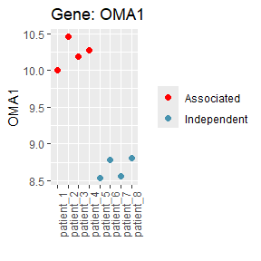

```
#> Plotting gene expression for gene: VOPP1
```

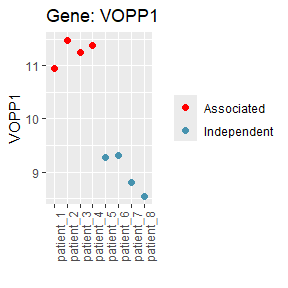

```
#> Plotting gene expression for gene: COL5A3
```

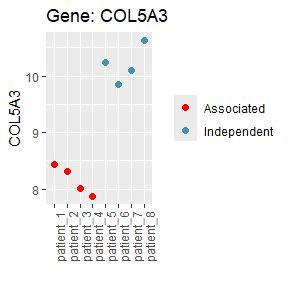

```
#> Plotting gene expression for gene: MMP10
```

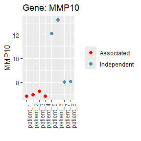

```
#> Plotting gene expression for gene: CDCA4
```

[1 more figures not shown]

```
#> Plotting gene expression for gene: TACSTD2

head(results)
#> log2 fold change (MLE): HPV_status Associated vs Independent
#> Wald test p-value: HPV_status Associated vs Independent
#> DataFrame with 6 rows and 6 columns
#>         baseMean log2FoldChange     lfcSE      stat    pvalue      padj
#>        <numeric>      <numeric> <numeric> <numeric> <numeric> <numeric>
#> A4GALT   438.986      -1.168114  0.681001 -1.715290 0.0862921  0.359863
#> AAAS     485.090       0.116862  0.677368  0.172524 0.8630256  0.956720
#> AACS     412.853      -1.235676  0.703735 -1.755881 0.0791088  0.344576
#> AAGAB   1116.256      -0.588544  0.392074 -1.501104 0.1333288  0.447441
#> AAK1     744.302       1.111357  0.653029  1.701849 0.0887838  0.365756
#> AAMDC    212.438      -1.218844  0.649871 -1.875516 0.0607217  0.294944
```

```r
### DEA:
results <- HTG_DEA(outliers= outliers_tutorial,
                   counts_data= counts_data_tutorial,
                   AnnotData_tutorial,
                   design_formula = "HPV_status",
                   heatmap_columns = c("HPV_status", "Recurrence"),
                   contrast = c("HPV_status", "Associated", "Independent"),
                   pattern = "^NC-|^POS-|^GDNA-|^ERCC-",
                   remove_outliers = TRUE,
                   percentage_gene = 0.2,
                   threshold_gene = 200,
                   threshold_subject = 10,
                   pCutoff = 5e-2,
                   apply_filtering = TRUE,
                   apply_lfc_shrinkage = TRUE,
                   extract_shrinkage = FALSE)
```

#### GSEA: GSEA() for HTG:

A GSEA analysis can be performed using the results from the DEA contrast. HTG_GSEA will generate plots and Excel files for easy interpretation.

```r
HTG_GSEA(res_tutorial)
```

[output not shown]

[output cut: 69 more lines]

[output not shown]

#### TME: HTG_TME () for HTG:

This function performs Tumor Microenvironment (TME) analysis, which will be stored in `TME_results`. You can access each method using `$`. This object contains results from three methodologies.

```r
TME_results<- HTG_TME(outliers= outliers_tutorial,
                      pattern= "^NC-|^POS-|^GDNA-|^ERCC-",
                      counts_data= counts_data_tutorial,
                      AnnotData= AnnotData_tutorial,
                      design_formula= "HPV_status",
                      remove_outliers = TRUE,
                      DEA = NULL)
```

```
#> [1] "Inicial gene number: 19394"
#> TPM normalization performed and stored on tpm_counts.csv
#> >>>--- This function is being optimised and we strongly recommend that you should set `source` as `local`....
#> [1] "Number of genes omitted during TPM normalization due to their length not being available in Biomart:   1086"
#> Performing normalization.
#>
#> >>> Running epic
#> Warning in (function (bulk, reference = NULL, mRNA_cell = NULL, mRNA_cell_sub = NULL, : The optimization didn't fully converge for some samples:
#> patient_3
#>  - check fit.gof for the convergeCode and convergeMessage
#>
#> >>> Running quantiseq
#>
#> Running quanTIseq deconvolution module
#> Gene expression normalization and re-annotation (arrays: FALSE)
#> Removing 17 noisy genes
#> Removing 15 genes with high expression in tumors
#> Signature genes found in data set: 132/138 (95.65%)
#> Mixture deconvolution (method: lsei)
#> Deconvolution successful!
#>
#> >>> Running xcell
#> results of the devonvolution will be stored in imm_epic.csv, imm_qti.csv and imm_xcell.csv
#> Are they in the same order?
#> Have to be true.
#> EPIC
#> [1] TRUE
#> qti
#> [1] TRUE
#> xcell
#> [1] TRUE
#> Attention: plot_cell_fraction_Average_cell_fraction will work for all methods. For xCell, it will display Enrichment Scores instead of percentages.
#> Apply the filtering and normality test for each dataset
#> Checking if All Values in Each Column Are Equal in dataset: quanTIseq
#> In dataset quanTIseq the following columns have the same value in all rows and will be excluded from the analysis:
#> [1] "Neutrophil"
#> Checking if All Values in Each Column Are Equal in dataset: EPIC
#> In dataset EPIC the following columns have the same value in all rows and will be excluded from the analysis:
#> character(0)
#> Checking if All Values in Each Column Are Equal in dataset: xcell
```

[output cut: 71 more lines]

```
#>    Cell_Type                        Test   p.value
#>    <chr>                            <chr>    <dbl>
#>  1 Myeloid_dendritic_cell_activated t-test  0.198
#>  2 B_cell                           t-test  0.0484
#>  3 T_cell_CD4+_memory               t-test  0.220
#>  4 T_cell_CD4+_naive                t-test  0.185
#>  5 T_cell_CD4+_(non-regulatory)     t-test  0.391
#>  6 T_cell_CD4+_central_memory       t-test  0.776
#>  7 T_cell_CD4+_effector_memory      t-test  0.182
#>  8 T_cell_CD8+_naive                t-test  0.171
#>  9 T_cell_CD8+                      t-test  0.0164
#> 10 T_cell_CD8+_central_memory       t-test  0.0146
#> # ℹ 29 more rows
#> GENERATING HEATMAPS
#> Heatmap of qti, EPIC and xcell will be stored on plots_TME_heatmap.pdf
```

```r
head(TME_results$EPIC)
```

```
#>                 B_cell Cancer_associated_fibroblast  T_cell_CD4+  T_cell_CD8+
#> patient_1 1.150729e-06                 2.016299e-06 9.454060e-10 2.425392e-06
#> patient_2 1.162535e-01                 2.177641e-02 1.561392e-01 1.032210e-03
#> patient_3 1.812948e-01                 8.256491e-03 7.200416e-02 2.920044e-06
#> patient_4 1.517297e-01                 5.777250e-02 8.969556e-07 1.326486e-06
#> patient_5 1.396394e-02                 4.308314e-02 6.416144e-02 2.171875e-09
#> patient_6 1.173785e-03                 6.562770e-02 5.454055e-02 3.029674e-06
#>           Endothelial_cell  Macrophage      NK_cell uncharacterized_cell
#> patient_1     3.117571e-08 0.999993600 8.033374e-07         2.726286e-09
#> patient_2     1.513580e-02 0.038318322 5.511060e-04         6.507934e-01
#> patient_3     4.132234e-02 0.109170000 1.448324e-03         5.865009e-01
#> patient_4     4.808822e-03 0.340783400 4.338030e-02         4.015231e-01
#> patient_5     1.639526e-02 0.026456960 1.301272e-08         8.359392e-01
#> patient_6     2.448703e-02 0.008433899 1.093331e-08         8.457340e-01
#>            HPV_status
#> patient_1  Associated
#> patient_2  Associated
#> patient_3  Associated
#> patient_4  Associated
#> patient_5 Independent
#> patient_6 Independent
```

```r
head(TME_results$QTI)
```

```
#>                B_cell Macrophage_M1 Macrophage_M2    Monocyte Neutrophil
#> patient_1 0.069908801   0.000000000    0.47458013 0.035577343          0
#> patient_2 0.134239640   0.027649080    0.09043049 0.011559290          0
#> patient_3 0.136095178   0.005503631    0.34483855 0.065454939          0
#> patient_4 0.080426018   0.125520772    0.21625401 0.001473265          0
#> patient_5 0.044623700   0.014932880    0.11713611 0.000000000          0
#> patient_6 0.006699906   0.038054563    0.04783640 0.000000000          0
#>               NK_cell T_cell_CD4+_(non-regulatory) T_cell_CD8+
#> patient_1 0.009145382                   0.00000000  0.06116945
#> patient_2 0.000000000                   0.30471172  0.03531690
#> patient_3 0.012846664                   0.05983765  0.05960699
#> patient_4 0.048619021                   0.00000000  0.16209930
#> patient_5 0.024217980                   0.00000000  0.00000000
#> patient_6 0.016230720                   0.00000000  0.00000000
#>           T_cell_regulatory_(Tregs) Myeloid_dendritic_cell uncharacterized_cell
#> patient_1               0.023104003                      0            0.3265149
#> patient_2               0.125286240                      0            0.2708066
#> patient_3               0.112300197                      0            0.2035162
#> patient_4               0.008229871                      0            0.3573777
#> patient_5               0.032973360                      0            0.7661160
#> patient_6               0.033105128                      0            0.8580733
#>            HPV_status
#> patient_1  Associated
#> patient_2  Associated
#> patient_3  Associated
#> patient_4  Associated
#> patient_5 Independent
#> patient_6 Independent
```

```r
head(TME_results$XCELL)
```

```
#>           Myeloid_dendritic_cell_activated       B_cell T_cell_CD4+_memory
#> patient_1                     3.082705e-18 3.155324e-01       0.000000e+00
#> patient_2                     5.147240e-19 4.665123e-01       1.328549e-01
#> patient_3                     1.073208e-18 5.027837e-01       6.250107e-02
#> patient_4                     0.000000e+00 1.984579e-01       1.055502e-18
#> patient_5                     8.241773e-18 3.868377e-03       3.349103e-19
#> patient_6                     0.000000e+00 4.558381e-18       0.000000e+00
#>           T_cell_CD4+_naive T_cell_CD4+_(non-regulatory)
#> patient_1      1.925551e-02                 0.000000e+00
#> patient_2      1.130897e-01                 9.152625e-02
#> patient_3      3.754398e-02                 0.000000e+00
#> patient_4      0.000000e+00                 0.000000e+00
#> patient_5      1.928309e-19                 7.599729e-18
#> patient_6      6.646919e-18                 0.000000e+00
#>           T_cell_CD4+_central_memory T_cell_CD4+_effector_memory
#> patient_1               0.000000e+00                0.000000e+00
#> patient_2               2.551973e-02                9.292065e-02
#> patient_3               0.000000e+00                9.932477e-02
#> patient_4               1.672849e-17                2.715178e-19
#> patient_5               1.643340e-02                4.647476e-19
#> patient_6               0.000000e+00                4.266006e-18
#>           T_cell_CD8+_naive  T_cell_CD8+ T_cell_CD8+_central_memory
#> patient_1      8.740664e-19 4.803232e-02               4.190523e-02
#> patient_2      3.557785e-02 1.427515e-01               1.247125e-01
#> patient_3      3.448572e-02 1.320651e-01               9.712064e-02
#> patient_4      3.030975e-02 9.535608e-02               8.948805e-02
#> patient_5      4.487133e-19 6.803360e-19               4.692817e-18
#> patient_6      1.477767e-20 9.536354e-19               3.838657e-03
#>           T_cell_CD8+_effector_memory Class-switched_memory_B_cell
#> patient_1                1.397381e-17                 7.063573e-02
#> patient_2                3.179827e-02                 1.564154e-01
#> patient_3                2.609685e-03                 1.663765e-01
#> patient_4                2.695730e-03                 6.641454e-02
#> patient_5                2.437879e-17                 2.574549e-02
#> patient_6                6.963297e-19                 4.373453e-19
#>           Common_lymphoid_progenitor Common_myeloid_progenitor
#> patient_1               4.455528e-18              0.000000e+00
#> patient_2               2.261100e-02              2.227240e-18
#> patient_3               9.347361e-03              0.000000e+00
#> patient_4               5.750150e-02              1.362306e-18
```

[output cut: 43 more lines]

```
#> patient_6       0.000000e+00     0.095582720    1.264443e-17
#>           T_cell_regulatory_(Tregs) immune_score stroma_score
#> patient_1              1.779964e-17 2.990312e-01 4.878840e-03
#> patient_2              0.000000e+00 4.935816e-01 2.255798e-02
#> patient_3              0.000000e+00 4.998010e-01 4.558515e-02
#> patient_4              3.759361e-18 2.279404e-01 2.903094e-02
#> patient_5              1.762743e-03 1.556536e-02 3.691756e-18
#> patient_6              0.000000e+00 4.807531e-18 1.384405e-02
#>           microenvironment_score  HPV_status
#> patient_1             0.30391000  Associated
#> patient_2             0.51613950  Associated
#> patient_3             0.54538610  Associated
#> patient_4             0.25697130  Associated
#> patient_5             0.01556536 Independent
#> patient_6             0.01384405 Independent
```

#### Survival analysis: HTG_survival() for HTG:

Survival analysis can be performed using the results from DEA (res), specific genes, or TME results. The function prioritizes inputs: first genes_to_use, then DEA results, and finally TME results if none are provided.

```r
############# survival using res
 HTG_survival(variable_01 = "Recurrence_01",
              time = "Time_to_death_surv",
              col_data = AnnotData_tutorial,
              counts_data = counts_data_tutorial,
              res = res_tutorial,
              method = "median",
              genes_to_use = NULL,
              TME = NULL,
              outliers = outliers_tutorial,
              pattern = "^NC-|^POS-|^GDNA-|^ERCC-",
              remove_outliers = TRUE)
```

```
#> FILTERING THE COUNT DATA. DELETING THE PROVES...
#> REMOVING OUTLIERS...
#> Normalizing data...
#> OBTAINING NORMALIEZ COUNTS...
#> Checking for duplicate columns
#> [1] "No duplicate columns."
#> Filtering data.
#> Selecting TOP 10 genes with the lowest padj
#> Starting survival analysis.
#>
#> Performing analysis for column:  LCP1
#> Using Median to determine cutoff...
#> MEDIAN CUT OFF:
#> [1] 2939.029
#> Fitting survival model
#> Summary of the fit
#> Call: survfit(formula = surv_formula, data = merged_data)
#>
#>                 LCP1_mRNA_expression=High
#>  time n.risk n.event survival std.err lower 95% CI upper 95% CI
#>  1164      2       1      0.5   0.354        0.125            1
#>  1287      1       1      0.0     NaN           NA           NA
#>
#>                 LCP1_mRNA_expression=Low
#>  time n.risk n.event survival std.err lower 95% CI upper 95% CI
#>  2458      2       1      0.5   0.354        0.125            1
#>  5844      1       1      0.0     NaN           NA           NA
#>
#> Performing log-rank test and obtaining p-value
#> Call:
#> survival::survdiff(formula = surv_formula, data = merged_data)
#>
#>                           N Observed Expected (O-E)^2/E (O-E)^2/V
#> LCP1_mRNA_expression=High 4        2    0.533     4.033      5.63
#> LCP1_mRNA_expression=Low  4        2    3.467     0.621      5.63
#>
#>  Chisq= 5.6  on 1 degrees of freedom, p= 0.02
#> P-value
#> [1] 0.01767673
#> Generating Kaplan-Meier plot
```

[output cut: 244 more lines]

```
#> Performing log-rank test and obtaining p-value
#> Call:
#> survival::survdiff(formula = surv_formula, data = merged_data)
#>
#>                              N Observed Expected (O-E)^2/E (O-E)^2/V
#> TACSTD2_mRNA_expression=High 4        2    3.467     0.621      5.63
#> TACSTD2_mRNA_expression=Low  4        2    0.533     4.033      5.63
#>
#>  Chisq= 5.6  on 1 degrees of freedom, p= 0.02
#> P-value
#> [1] 0.01767673
#> Generating Kaplan-Meier plot
#> Plots saved in survival_analysis_plots_top_10.pdf
#> png
#>   2
```

```r
 # USING SPECIFIC GENES
 HTG_survival(variable_01 = "Recurrence_01",
              time = "Time_to_death_surv",
              col_data = AnnotData_tutorial,
              counts_data = counts_data_tutorial,
              res = NULL,
              method = "quartiles",
              genes_to_use = c("LCP1", "OMA1"),
              TME = NULL,
              outliers = outliers_tutorial,
              pattern = "^NC-|^POS-|^GDNA-|^ERCC-",
              remove_outliers = TRUE)
```

```
#> FILTERING THE COUNT DATA. DELETING THE PROVES...
#> REMOVING OUTLIERS...
#> Normalizing data...
#> OBTAINING NORMALIEZ COUNTS...
#> Checking for duplicate columns
#> [1] "No duplicate columns."
#> Filtering data.
#> Using provided genes
#> Starting survival analysis.
#>
#> Performing analysis for column:  LCP1
#> Using Quartiles to determine cutoff...
#> Quartile 1 (Q1):  868.7876
#> Quartile 3 (Q3):  7834.828
#> Using Q3 Quartile to determine cutoff...
#> Fitting survival model
#> Summary of the fit
#> Call: survfit(formula = surv_formula, data = merged_data)
#>
#>                 LCP1_mRNA_expression=High
#>      time n.risk n.event survival std.err lower 95% CI upper 95% CI
#>
#>                 LCP1_mRNA_expression=Low
#>  time n.risk n.event survival std.err lower 95% CI upper 95% CI
#>  1164      6       1    0.833   0.152       0.5827            1
#>  1287      5       1    0.667   0.192       0.3786            1
#>  2458      2       1    0.333   0.255       0.0746            1
#>  5844      1       1    0.000     NaN           NA           NA
#>
#> Performing log-rank test and obtaining p-value
#> Call:
#> survival::survdiff(formula = surv_formula, data = merged_data)
#>
#>                           N Observed Expected (O-E)^2/E (O-E)^2/V
#> LCP1_mRNA_expression=High 2        0        0       NaN       NaN
#> LCP1_mRNA_expression=Low  6        4        4         0       NaN
#>
#>  Chisq= 0  on 0 degrees of freedom, p= 1
#> P-value
#> [1] 1
```

[output cut: 24 more lines]

```
#> Performing log-rank test and obtaining p-value
#> Call:
#> survival::survdiff(formula = surv_formula, data = merged_data)
#>
#>                           N Observed Expected (O-E)^2/E (O-E)^2/V
#> OMA1_mRNA_expression=High 2        1    0.167     4.167         5
#> OMA1_mRNA_expression=Low  6        3    3.833     0.181         5
#>
#>  Chisq= 5  on 1 degrees of freedom, p= 0.03
#> P-value
#> [1] 0.02534732
#> Generating Kaplan-Meier plot
#> Plots saved in survival_analysis_plots_SELECTED_GENES.pdf
#> png
#>   2
```

```r
 # USING TME DATA
 HTG_survival(variable_01 = "Recurrence_01",
              time = "Time_to_death_surv",
              col_data = AnnotData_tutorial,
              counts_data = counts_data_tutorial,
              res = NULL,
              method = "maxstat",
              genes_to_use = NULL,
              TME = TME_data_tutorial$EPIC,
              outliers = outliers_tutorial,
              pattern = "^NC-|^POS-|^GDNA-|^ERCC-",
              remove_outliers = TRUE)
```

```
#> FILTERING THE COUNT DATA. DELETING THE PROVES...
#> REMOVING OUTLIERS...
#> Normalizing data...
#> OBTAINING NORMALIEZ COUNTS...
#> Checking for duplicate columns
#> [1] "No duplicate columns."
#> Filtering data.
#> Using rownames from TME
#> Starting survival analysis.
#>
#> Performing analysis for column:  B_cell
#> Using MAXSTAT to determine cutoff...
#> MAXSTAT CUT OFF:
#> estimated cutpoint
#>         0.01396394
#> Fitting survival model
#> Summary of the fit
#> Call: survfit(formula = surv_formula, data = merged_data)
#>
#>                 B_cell=High
#>  time n.risk n.event survival std.err lower 95% CI upper 95% CI
#>  1164      2       1      0.5   0.354        0.125            1
#>  2458      1       1      0.0     NaN           NA           NA
#>
#>                 B_cell=Low
#>  time n.risk n.event survival std.err lower 95% CI upper 95% CI
#>  1287      4       1     0.75   0.217        0.426            1
#>  5844      1       1     0.00     NaN           NA           NA
#>
#> Performing log-rank test and obtaining p-value
#> Call:
#> survival::survdiff(formula = surv_formula, data = merged_data)
#>
#>             N Observed Expected (O-E)^2/E (O-E)^2/V
#> B_cell=High 4        2     1.03     0.904      1.48
#> B_cell=Low  4        2     2.97     0.315      1.48
#>
#>  Chisq= 1.5  on 1 degrees of freedom, p= 0.2
#> P-value
#> [1] 0.2240827
```

[output cut: 226 more lines]

```
#> Performing log-rank test and obtaining p-value
#> Call:
#> survival::survdiff(formula = surv_formula, data = merged_data)
#>
#>                           N Observed Expected (O-E)^2/E (O-E)^2/V
#> uncharacterized_cell=High 5        2      3.1      0.39      2.47
#> uncharacterized_cell=Low  3        2      0.9      1.34      2.47
#>
#>  Chisq= 2.5  on 1 degrees of freedom, p= 0.1
#> P-value
#> [1] 0.1160831
#> Generating Kaplan-Meier plot
#> Plots saved in survival_analysis_plots_TME.pdf
#> png
#>   2
```

## RNAseq:

Now let’s show how it works with RNAseq You can download the example Excel files from the following link: https://github.com/ISGLOBAL-Rakislova-Lab/HTGAnalyzer/tree/main/SUPLEMENTARY_OUTPUT

### HTG_auto() for RNAseq:

#### HTG_auto(): All the analysis for RNAseq:

Imagine you have RNAseq data and aim to perform a full suite of analyses, including Differential Expression Analysis (DEA), Tumor Microenvironment (TME) analysis, Survival Analysis, and Gene Set Enrichment Analysis (GSEA).

The following code shows how to run each of these analyses. We’ve highlighted the variables that can be adjusted in the functions, so you’re aware of them. However, you can leave them as they are if the default settings meet your requirements.

```r
result <- HTG_auto(
  counts_file_path = "~/HTGAnalyzer/counts_RNAseq.xlsx",  # path to counts data
  file_type = "RNAseq",  # Tipe of file
  AnnotData_file_path = "~/HTGAnalyzer/annotdata.xlsx",  # path to annotdata.
  pattern = NULL,
  save_csv = TRUE,
  csv_file = "QC_results.csv",
  design_formula = "HPV_status",
  percentage_gene = 0.2,
  threshold_gene = 200,
  threshold_subject = 10,
  genes_to_use = c("CCND1", "MMP10", "CTTN"), # Genes used for survival analysis (optional)
  heatmap_columns = c("HPV_status", "Ciclina_D1"),  # Columns for the heatmap
  contrast = c("HPV_status", "Associated", "Independent"),  # Contrast for differential analysis
  pCutoff = 5e-2,
  variable_01 = "Recurrence_01",   # Variable for analysis
  time = "Time_to_death_surv",  # Time for survival analysis
  DEA = TRUE,
  remove_outliers = TRUE,
  GSEA = TRUE,
  generate_heatmap = TRUE,
  TME = TRUE,
  survival_analysis = TRUE
)
```

**NOTE:** remember that RNAseq data doesn’t have probes and doesn’t pass for `HTG_QC()`as we did with HTG data.

The code above is an example. Some of the parameters have default values in the function, but they are included here for clarity. Refer to the function documentation for more details on each parameter.

#### HTG_auto(): skipping an analysis for RNAseq:

If you’d like to run some analyses but skip others (for example, leaving out the survival analysis and GSEA), simply set the corresponding parameter to FALSE. Here’s an example where the survival and GSEA analyses are not included:

In cases where a specific analysis requires certain data columns that you don’t have (such as the survival analysis needing variable_01 and time columns), you can set those variables to NULL to bypass that analysis.

```r
result <- HTG_auto(
  counts_file_path = "~/HTGAnalyzer/counts_RNAseq.xlsx",  # path to counts data
  file_type = "RNAseq",  # Tipe of file
  AnnotData_file_path = "~/HTGAnalyzer/annotdata_RNAseq.xlsx",  # path to annotdata.
  pattern = NULL,
  save_csv = TRUE,
  csv_file = "QC_results.csv",
  design_formula = "HPV_status",
  percentage_gene = 0.2,
  threshold_gene = 200,
  threshold_subject = 10,
  genes_to_use = c("CCND1", "MMP10", "CTTN"),  # Genes used for survival analysis (optional)
  heatmap_columns = c("HPV_status", "Ciclina_D1"),
  contrast = c("HPV_status", "Associated", "Independent"),  # Contrast for differential analysis
  pCutoff = 5e-2,
  variable_01 = "Recurrence_01",  # Variable for survival analysis
  time = "Time_to_death_surv",  # Time for survival analysis
  DEA = TRUE,
  remove_outliers = TRUE,
  GSEA = FALSE,
  generate_heatmap = TRUE,
  TME = TRUE,
  survival_analysis = FALSE  # Skip survival analysis by setting this parameter to FALSE
)
```

In this example, survival analysis is skipped by setting `survival_analysis = FALSE` and GSA by setting `GSEA = FALSE`. The output will indicate that the survival analysis step has been skipped.

### STEP BY STEP for RNAseq:

What if you already had some analysis or you want to get more control over it? Don’t worry we have the solution.Let’s go `step-by-step`, starting with data import:

#### Load data: HTG_import_counts() for RNAseq:

You can upload data directly from HTG Edge Reveal using this function.

```r
## LOAD COUNTS DATA

htg_data <- HTG_import_counts("~/HTGAnalyzer/counts.xlsx", "RNAseq")
head(htg_data)

## LOAD ANNOTDATA
annotdata<- readxl::read_excel("~/HTGAnalyzer/annotdata.xlsx")
head(annotdata)
```

**NOTE:** For the following functions, we’ll use tutorial data from the package. If you want to try with your data, replace `counts_data_tutorial` with `htg_data`.

#### HTG_quant_to_qual() for RNAseq:

If you need to transform a quantitative column to a qualitative one, you can use this function.

```r
head(AnnotData_tutorial)
```

```
#>                  id  HPV_status Ciclina_D1 FIGO_2021_STAGE Recurrence
#> patient_1 patient_1  Associated         10            IIIB        yes
#> patient_2 patient_2  Associated         50              II         no
#> patient_3 patient_3  Associated         NA            IIIC         no
#> patient_4 patient_4  Associated          0              IB        yes
#> patient_5 patient_5 Independent         50              IB        yes
#> patient_6 patient_6 Independent         80              IB         no
#>           Recurrence_01 Time_to_death_surv Ciclina_D12
#> patient_1             1               1287         low
#> patient_2             0                510         low
#> patient_3             0                762        <NA>
#> patient_4             1               1164         low
#> patient_5             1               5844         low
#> patient_6             0               1436        high
```

```r
AnnotData_tutorial <- HTG_quant_to_qual(AnnotData_tutorial,  # Dataset to modify
                                        "Ciclina_D1",  # Column to transform
                                        60,  # Threshold to categorize the data
                                        "high",  # Value for entries greater than 60
                                        "low")  # Value for entries less than 60
head(AnnotData_tutorial)
```

```
#>                  id  HPV_status Ciclina_D1 FIGO_2021_STAGE Recurrence
#> patient_1 patient_1  Associated         10            IIIB        yes
#> patient_2 patient_2  Associated         50              II         no
#> patient_3 patient_3  Associated         NA            IIIC         no
#> patient_4 patient_4  Associated          0              IB        yes
#> patient_5 patient_5 Independent         50              IB        yes
#> patient_6 patient_6 Independent         80              IB         no
#>           Recurrence_01 Time_to_death_surv Ciclina_D12
#> patient_1             1               1287         low
#> patient_2             0                510         low
#> patient_3             0                762        <NA>
#> patient_4             1               1164         low
#> patient_5             1               5844         low
#> patient_6             0               1436        high
```

#### HTG_subset() for RNAseq:

Now that you have the counts data loaded, you can search for certain genes of interest, look for specific probes, or filter results from DEA. This function can also normalize the data by TPM (Transcripts Per Million).

```r
 # Subset rows with the prefix "ERCC"
 cts_ERCC <- HTG_subset(counts_data_RNAseq, "ERCC")
```

```
#> Subsetting without normalization...
#> Dimensions: 9 11
```

```r
 # Subset rows with the prefix "POS"
 cts_POS <- HTG_subset(counts_data_RNAseq, "POS")
```

```
#> Subsetting without normalization...
#> Dimensions: 1 11
```

```r
 # Subset rows with the prefix "NC"
 cts_NC <- HTG_subset(counts_data_RNAseq, "NC")
```

```
#> Subsetting without normalization...
#> Dimensions: 46 11
```

```r
# Subset rows with the prefix "GDNA"
 cts_GDNA <- HTG_subset(counts_data_RNAseq, "GDNA")
```

```
#> Subsetting without normalization...
#> Dimensions: 0 11
```

```r
 # Subset rows with the prefix "ZZZ3"
 cts_ZZZ3 <- HTG_subset(counts_data_RNAseq, "ZZZ3")
```

```
#> Subsetting without normalization...
#> Dimensions: 1 11
```

```r
  # Subset rows with the prefix "ZZZ3" and normalize the data
 cts_ZZZ3 <- HTG_subset(counts_data_RNAseq, "ZZZ3", normalize = TRUE)
```

```
#> Normalizing data using TPM (Transcripts Per Million)...
#> Dimensions: 1 11
```

```r
 resAAAS<- HTG_subset(res_tutorial, "AAAS")
```

```
#> Subsetting without normalization...
#> Dimensions: 1 6
```

#### HTG_calculate_summary_stats() for RNAseq:

As RNaseq doen’t have a QC() if is needed you can perform a summary stats.

```r
summary <- HTG_calculate_summary_stats(counts_data_RNAseq, pattern = NULL)
```

#### Perform all the analysis: HTG_analysis() for RNAseq:

Now that you know which variables are outliers, you can perform any of the analyses.This function will remove the outliers, perform DEA, TME, survival analysis, and GSEA. If you want to perform each step separately, you can use the functions `HTG_GSEA()`, `HTG_DEA()`, `HTG_TME()`, and `HTG_survival()`.

```r
ALL_done <- HTG_analysis(outliers = NULL, # RNAseq doen't have outliers.
                         pattern = NULL,
                         counts_data = counts_data_RNAseq,
                         col_data = AnnotData_tutorial,
                         design_formula = "HPV_status",
                         percentage_gene = 0.2,
                         threshold_gene = 200,
                         threshold_subject = 10,
                         genes_to_use = c("CCND1", "MMP10", "CTTN"),
                         heatmap_columns = c("HPV_status","Ciclina_D1"),
                         contrast = c("HPV_status", "Associated", "Independent"),
                         pCutoff = 5e-2,
                         variable_01 = "Recurrence_01",
                         time = "Time_to_death_surv",
                         DEA = TRUE,
                         remove_outliers = FALSE, #set false because don't have outliers.
                         GSEA = FALSE,
                         generate_heatmap = TRUE,
                         TME = TRUE,
                         survival_analysis = FALSE)
```

```
#> STARTING THE DIFERENTIAN EXPRESSION ANALYSIS.
#> [1] "HPV_status"
#>
#> BEFORE FILTERING
#> class: DESeqDataSet
#> dim: 19394 11
#> metadata(1): version
#> assays(1): counts
#> rownames(19394): A3GALT2 A4GALT ... ZZEF1 ZZZ3
#> rowData names(0):
#> colnames(11): patient_1 patient_10 ... patient_8 patient_9
#> colData names(8): id HPV_status ... Time_to_death_surv Ciclina_D12
#>
#>
#> AFTER FILTERING
#> class: DESeqDataSet
#> dim: 10491 11
#> metadata(1): version
#> assays(1): counts
#> rownames(10491): A4GALT AAAS ... ZZEF1 ZZZ3
#> rowData names(0):
#> colnames(11): patient_1 patient_10 ... patient_8 patient_9
#> colData names(8): id HPV_status ... Time_to_death_surv Ciclina_D12
#>
#> -- note: fitType='parametric', but the dispersion trend was not well captured by the
#>    function: y = a/x + b, and a local regression fit was automatically substituted.
#>    specify fitType='local' or 'mean' to avoid this message next time.
#> RESULTS OF VST NORMALIZATION
#> class: DESeqTransform
#> dim: 10491 11
#> metadata(1): version
#> assays(1): ''
#> rownames(10491): A4GALT AAAS ... ZZEF1 ZZZ3
#> rowData names(4): baseMean baseVar allZero dispFit
#> colnames(11): patient_1 patient_10 ... patient_8 patient_9
#> colData names(9): id HPV_status ... Ciclina_D12 sizeFactor
#>
#> -- note: fitType='parametric', but the dispersion trend was not well captured by the
#>    function: y = a/x + b, and a local regression fit was automatically substituted.
#>    specify fitType='local' or 'mean' to avoid this message next time.
```

[output cut: 148 more lines]

```
#>    <chr>                            <chr>    <dbl>
#>  1 Myeloid_dendritic_cell_activated t-test 0.247
#>  2 B_cell                           t-test 0.0116
#>  3 T_cell_CD4+_memory               t-test 0.0826
#>  4 T_cell_CD4+_naive                t-test 0.142
#>  5 T_cell_CD4+_(non-regulatory)     t-test 0.391
#>  6 T_cell_CD4+_central_memory       t-test 0.656
#>  7 T_cell_CD4+_effector_memory      t-test 0.221
#>  8 T_cell_CD8+_naive                t-test 0.0160
#>  9 T_cell_CD8+                      t-test 0.00677
#> 10 T_cell_CD8+_central_memory       t-test 0.00848
#> # ℹ 29 more rows
#> GENERATING HEATMAPS
#> Heatmap of qti, EPIC and xcell will be stored on plots_TME_heatmap.pdf
#> Skipping survival analysis.
```

#### Differentia expression analysis: HTG_DEA() for RNAseq:

If you want more control, such as applying extra filtering or performing LFC shrinkage, `HTG_DEA()` will provide more options.

[output not shown]

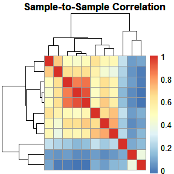

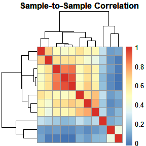

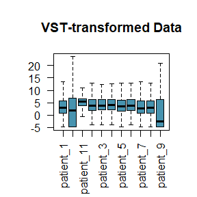

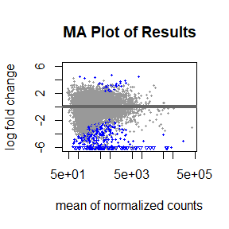

```
#> NULL
#> Plotting gene expression for gene: PPP2R2C
```

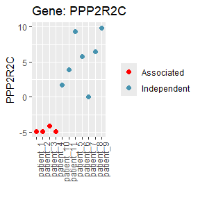

```
#> Plotting gene expression for gene: PDZK1IP1
```

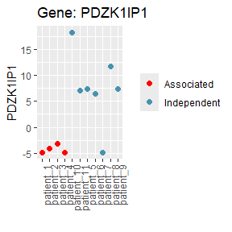

```
#> Plotting gene expression for gene: MMP10
```

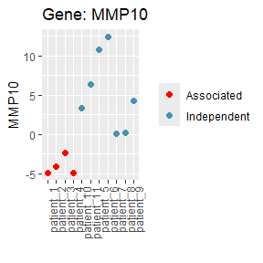

```
#> Plotting gene expression for gene: LYPD3
```

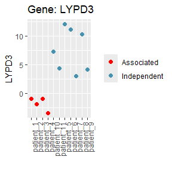

```
#> Plotting gene expression for gene: IRF6
```

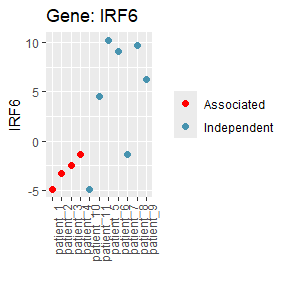

```
#> Plotting gene expression for gene: IL20RB
```

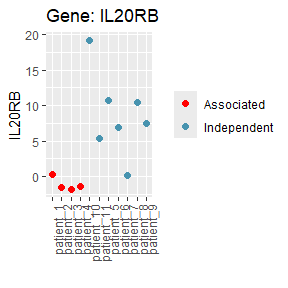

```
#> Plotting gene expression for gene: IGSF3
```

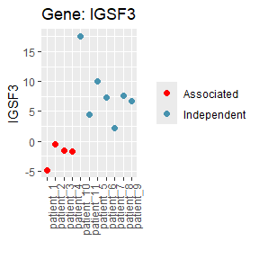

```
#> Plotting gene expression for gene: KRT80
```

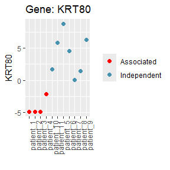

```
#> Plotting gene expression for gene: SULT2B1
```

[1 more figures not shown]

```
#> Plotting gene expression for gene: MMP13

head(results)
#> log2 fold change (MLE): HPV_status Associated vs Independent
#> Wald test p-value: HPV_status Associated vs Independent
#> DataFrame with 6 rows and 6 columns
#>         baseMean log2FoldChange     lfcSE      stat    pvalue      padj
#>        <numeric>      <numeric> <numeric> <numeric> <numeric> <numeric>
#> A4GALT  264.6559      -0.859248  0.971880 -0.884109  0.376637  0.883436
#> AAAS    241.9723       0.651588  1.092950  0.596174  0.551059  0.935317
#> AACS    192.2601      -0.465598  1.141494 -0.407884  0.683359  0.961809
#> AAGAB   516.4116       0.222419  1.069095  0.208044  0.835194  0.979410
#> AAK1    484.0285       0.746603  0.707829  1.054779  0.291527  0.836475
#> AAMDC    92.2931      -0.350702  1.276492 -0.274739  0.783517  0.975221
```

```r
### DEA:
results <- HTG_DEA(outliers= NULL,
                   counts_data= counts_data_RNAseq,
                   AnnotData_tutorial,
                   design_formula = "HPV_status",
                   heatmap_columns = c("HPV_status", "Recurrence"),
                   contrast = c("HPV_status", "Associated", "Independent"),
                   pattern = NULL,
                   remove_outliers = TRUE,
                   percentage_gene = 0.2,
                   threshold_gene = 200,
                   threshold_subject = 10,
                   pCutoff = 5e-2,
                   apply_filtering = TRUE,
                   apply_lfc_shrinkage = TRUE,
                   extract_shrinkage = FALSE)
```

#### GSEA: GSEA() for RNAseq:

A GSEA analysis can be performed using the results from the DEA contrast. HTG_GSEA will generate plots and Excel files for easy interpretation.

```r
HTG_GSEA(res_tutorial)
```

[output not shown]

[output cut: 60 more lines]

[output not shown]

#### TME: HTG_TME () for RNAseq:

This function performs Tumor Microenvironment (TME) analysis, which will be stored in `TME_results`. You can access each method using `$`. This object contains results from three methodologies.

```r
TME_results<- HTG_TME(outliers= NULL,
                      pattern= NULL,
                      counts_data= counts_data_RNAseq,
                      AnnotData= AnnotData_tutorial,
                      design_formula= "HPV_status",
                      remove_outliers = FALSE,
                      DEA = NULL)
```

```
#> [1] "Inicial gene number: 19394"
#> TPM normalization performed and stored on tpm_counts.csv
#> >>>--- This function is being optimised and we strongly recommend that you should set `source` as `local`....
#> [1] "Number of genes omitted during TPM normalization due to their length not being available in Biomart:   1086"
#> Performing normalization.
#>
#> >>> Running epic
#> Warning in (function (bulk, reference = NULL, mRNA_cell = NULL, mRNA_cell_sub = NULL, : The optimization didn't fully converge for some samples:
#> patient_3
#>  - check fit.gof for the convergeCode and convergeMessage
#>
#> >>> Running quantiseq
#>
#> Running quanTIseq deconvolution module
#> Gene expression normalization and re-annotation (arrays: FALSE)
#> Removing 17 noisy genes
#> Removing 15 genes with high expression in tumors
#> Signature genes found in data set: 132/138 (95.65%)
#> Mixture deconvolution (method: lsei)
#> Deconvolution successful!
#>
#> >>> Running xcell
#> results of the devonvolution will be stored in imm_epic.csv, imm_qti.csv and imm_xcell.csv
#> Are they in the same order?
#> Have to be true.
#> EPIC
#> [1] TRUE
#> qti
#> [1] TRUE
#> xcell
#> [1] TRUE
#> Attention: plot_cell_fraction_Average_cell_fraction will work for all methods. For xCell, it will display Enrichment Scores instead of percentages.
#> Apply the filtering and normality test for each dataset
#> Checking if All Values in Each Column Are Equal in dataset: quanTIseq
#> In dataset quanTIseq the following columns have the same value in all rows and will be excluded from the analysis:
#> character(0)
#> Checking if All Values in Each Column Are Equal in dataset: EPIC
#> In dataset EPIC the following columns have the same value in all rows and will be excluded from the analysis:
#> character(0)
#> Checking if All Values in Each Column Are Equal in dataset: xcell
```

[output cut: 73 more lines]

```
#>    Cell_Type                        Test   p.value
#>    <chr>                            <chr>    <dbl>
#>  1 Myeloid_dendritic_cell_activated t-test 0.247
#>  2 B_cell                           t-test 0.0116
#>  3 T_cell_CD4+_memory               t-test 0.0826
#>  4 T_cell_CD4+_naive                t-test 0.142
#>  5 T_cell_CD4+_(non-regulatory)     t-test 0.391
#>  6 T_cell_CD4+_central_memory       t-test 0.656
#>  7 T_cell_CD4+_effector_memory      t-test 0.221
#>  8 T_cell_CD8+_naive                t-test 0.0160
#>  9 T_cell_CD8+                      t-test 0.00677
#> 10 T_cell_CD8+_central_memory       t-test 0.00848
#> # ℹ 29 more rows
#> GENERATING HEATMAPS
#> Heatmap of qti, EPIC and xcell will be stored on plots_TME_heatmap.pdf
```

```r
head(TME_results$EPIC)
```

```
#>                  B_cell Cancer_associated_fibroblast  T_cell_CD4+  T_cell_CD8+
#> patient_1  1.150729e-06                 2.016299e-06 9.454060e-10 2.425392e-06
#> patient_10 1.865684e-02                 1.951744e-03 3.278105e-02 1.210909e-08
#> patient_11 2.155160e-02                 2.694712e-03 3.723145e-02 3.357117e-02
#> patient_2  1.162535e-01                 2.177641e-02 1.561392e-01 1.032210e-03
#> patient_3  1.812948e-01                 8.256491e-03 7.200416e-02 2.920044e-06
#> patient_4  1.517297e-01                 5.777250e-02 8.969556e-07 1.326486e-06
#>            Endothelial_cell  Macrophage      NK_cell uncharacterized_cell
#> patient_1      3.117571e-08 0.999993600 8.033374e-07         2.726286e-09
#> patient_10     6.217918e-03 0.016243630 7.745980e-03         9.164028e-01
#> patient_11     4.903101e-02 0.005872793 1.749065e-03         8.482982e-01
#> patient_2      1.513580e-02 0.038318322 5.511060e-04         6.507934e-01
#> patient_3      4.132234e-02 0.109170000 1.448324e-03         5.865009e-01
#> patient_4      4.808822e-03 0.340783400 4.338030e-02         4.015231e-01
#>             HPV_status
#> patient_1   Associated
#> patient_10 Independent
#> patient_11 Independent
#> patient_2   Associated
#> patient_3   Associated
#> patient_4   Associated
```

```r
head(TME_results$QTI)
```

```
#>                B_cell Macrophage_M1 Macrophage_M2    Monocyte Neutrophil
#> patient_1  0.06990880  0.000000e+00   0.474580130 0.035577343          0
#> patient_10 0.00000000  5.268426e-06   0.008705942 0.000000000          0
#> patient_11 0.11031970  2.848635e-02   0.258826850 0.042369490          0
#> patient_2  0.13423964  2.764908e-02   0.090430490 0.011559290          0
#> patient_3  0.13609518  5.503631e-03   0.344838553 0.065454939          0
#> patient_4  0.08042602  1.255208e-01   0.216254015 0.001473265          0
#>                NK_cell T_cell_CD4+_(non-regulatory) T_cell_CD8+
#> patient_1  0.009145382                   0.00000000  0.06116945
#> patient_10 0.000000000                   0.00000000  0.00000000
#> patient_11 0.055631630                   0.00000000  0.00000000
#> patient_2  0.000000000                   0.30471172  0.03531690
#> patient_3  0.012846664                   0.05983765  0.05960699
#> patient_4  0.048619021                   0.00000000  0.16209930
#>            T_cell_regulatory_(Tregs) Myeloid_dendritic_cell
#> patient_1                0.023104003                      0
#> patient_10               0.074409150                      0
#> patient_11               0.074404590                      0
#> patient_2                0.125286240                      0
#> patient_3                0.112300197                      0
#> patient_4                0.008229871                      0
#>            uncharacterized_cell  HPV_status
#> patient_1             0.3265149  Associated
#> patient_10            0.9168796 Independent
#> patient_11            0.4299614 Independent
#> patient_2             0.2708066  Associated
#> patient_3             0.2035162  Associated
#> patient_4             0.3573777  Associated
```

```r
head(TME_results$XCELL)
```

```
#>            Myeloid_dendritic_cell_activated      B_cell T_cell_CD4+_memory
#> patient_1                      3.704441e-02 0.325428700       1.142668e-01
#> patient_10                     0.000000e+00 0.069585870       0.000000e+00
#> patient_11                     1.825679e-17 0.005666945       1.658565e-19
#> patient_2                      7.274085e-19 0.465249000       3.324771e-01
#> patient_3                      1.298727e-02 0.502043800       2.299917e-01
#> patient_4                      7.658966e-18 0.209639900       5.325605e-02
#>            T_cell_CD4+_naive T_cell_CD4+_(non-regulatory)
#> patient_1       4.735101e-02                 5.191434e-18
#> patient_10      2.721425e-17                 0.000000e+00
#> patient_11      0.000000e+00                 0.000000e+00
#> patient_2       1.129919e-01                 8.307792e-02
#> patient_3       3.391430e-02                 1.631098e-19
#> patient_4       2.384884e-18                 1.818445e-17
#>            T_cell_CD4+_central_memory T_cell_CD4+_effector_memory
#> patient_1                1.358802e-17                1.042981e-17
#> patient_10               5.542262e-18                1.330074e-18
#> patient_11               4.254897e-17                5.249508e-17
#> patient_2                2.889525e-02                1.845534e-01
#> patient_3                4.304898e-03                2.041590e-01
#> patient_4                1.440364e-17                1.399956e-18
#>            T_cell_CD8+_naive T_cell_CD8+ T_cell_CD8+_central_memory
#> patient_1         0.03974244  0.08203368               5.154995e-02
#> patient_10        0.00000000  0.00000000               0.000000e+00
#> patient_11        0.00000000  0.00000000               2.310697e-17
#> patient_2         0.08857475  0.17772240               1.113198e-01
#> patient_3         0.08616049  0.16266110               8.185110e-02
#> patient_4         0.07952526  0.14421760               6.882800e-02
#>            T_cell_CD8+_effector_memory Class-switched_memory_B_cell
#> patient_1                 4.787293e-02                   0.06874662
#> patient_10                2.857536e-18                   0.00000000
#> patient_11                0.000000e+00                   0.00000000
#> patient_2                 1.482160e-01                   0.15564710
#> patient_3                 1.165878e-01                   0.16540470
#> patient_4                 1.325500e-01                   0.06442109
#>            Common_lymphoid_progenitor Common_myeloid_progenitor
#> patient_1                9.028999e-03              6.235078e-19
#> patient_10               4.590643e-18              8.178118e-18
#> patient_11               2.307430e-02              3.095361e-01
#> patient_2                3.899960e-02              0.000000e+00
```

[output cut: 43 more lines]

```
#> patient_4        5.101980e-18    3.745663e-01    4.812461e-18
#>            T_cell_regulatory_(Tregs) immune_score stroma_score
#> patient_1               3.903347e-18   0.35499380 5.966090e-04
#> patient_10              1.785058e-02   0.09337039 1.915915e-17
#> patient_11              0.000000e+00   0.05980657 3.342654e-02
#> patient_2               0.000000e+00   0.52851460 1.349824e-03
#> patient_3               3.003288e-18   0.54084280 2.738785e-02
#> patient_4               1.165112e-17   0.29118570 1.772281e-02
#>            microenvironment_score  HPV_status
#> patient_1              0.35559040  Associated
#> patient_10             0.09337039 Independent
#> patient_11             0.09323310 Independent
#> patient_2              0.52986440  Associated
#> patient_3              0.56823060  Associated
#> patient_4              0.30890850  Associated
```

#### Survival analysis: HTG_survival() for RNAseq:

Survival analysis can be performed using the results from DEA (res), specific genes, or TME results. The function prioritizes inputs: first genes_to_use, then DEA results, and finally TME results if none are provided.

```r
# survival using res
HTG_survival(variable_01 = "Recurrence_01",
             time = "Time_to_death_surv",
             col_data = AnnotData_tutorial,
             counts_data = counts_data_tutorial,
             res = res_tutorial,
             method = "median",
             genes_to_use = NULL,
             TME = NULL,
             outliers = NULL,
             pattern = NULL,
             remove_outliers = FALSE)
```

```
#> Normalizing data...
#> OBTAINING NORMALIEZ COUNTS...
#> Checking for duplicate columns
#> [1] "No duplicate columns."
#> Filtering data.
#> Selecting TOP 10 genes with the lowest padj
#> Starting survival analysis.
#>
#> Performing analysis for column:  LCP1
#> Using Median to determine cutoff...
#> MEDIAN CUT OFF:
#> [1] 494.7313
#> Fitting survival model
#> Summary of the fit
#> Call: survfit(formula = surv_formula, data = merged_data)
#>
#>                 LCP1_mRNA_expression=High
#>  time n.risk n.event survival std.err lower 95% CI upper 95% CI
#>  1164      3       1    0.667   0.272       0.2995            1
#>  1287      2       1    0.333   0.272       0.0673            1
#>
#>                 LCP1_mRNA_expression=Low
#>  time n.risk n.event survival std.err lower 95% CI upper 95% CI
#>   234      6       1    0.833   0.152       0.5827            1
#>  2458      2       1    0.417   0.304       0.0996            1
#>  5844      1       1    0.000     NaN           NA           NA
#>
#> Performing log-rank test and obtaining p-value
#> Call:
#> survival::survdiff(formula = surv_formula, data = merged_data)
#>
#>                           N Observed Expected (O-E)^2/E (O-E)^2/V
#> LCP1_mRNA_expression=High 5        2     1.35     0.308     0.565
#> LCP1_mRNA_expression=Low  6        3     3.65     0.114     0.565
#>
#>  Chisq= 0.6  on 1 degrees of freedom, p= 0.5
#> P-value
#> [1] 0.4524268
#> Generating Kaplan-Meier plot
#> Plots saved in survival_analysis_plots_top_10.pdf
```

[output cut: 251 more lines]

```
#> Performing log-rank test and obtaining p-value
#> Call:
#> survival::survdiff(formula = surv_formula, data = merged_data)
#>
#>                              N Observed Expected (O-E)^2/E (O-E)^2/V
#> TACSTD2_mRNA_expression=High 5        2     3.55      0.68      3.27
#> TACSTD2_mRNA_expression=Low  6        3     1.45      1.67      3.27
#>
#>  Chisq= 3.3  on 1 degrees of freedom, p= 0.07
#> P-value
#> [1] 0.07035001
#> Generating Kaplan-Meier plot
#> Plots saved in survival_analysis_plots_top_10.pdf
#> png
#>   2
```

```r
# USING SPECIFIC GENES
HTG_survival(variable_01 = "Recurrence_01",
             time = "Time_to_death_surv",
             col_data = AnnotData_tutorial,
             counts_data = counts_data_tutorial,
             res = NULL,
             method = "quartiles",
             genes_to_use = c("LCP1", "OMA1"),
             TME = NULL,
             outliers = NULL,
             pattern = NULL,
             remove_outliers = FALSE)
```

```
#> Normalizing data...
#> OBTAINING NORMALIEZ COUNTS...
#> Checking for duplicate columns
#> [1] "No duplicate columns."
#> Filtering data.
#> Using provided genes
#> Starting survival analysis.
#>
#> Performing analysis for column:  LCP1
#> Using Quartiles to determine cutoff...
#> Quartile 1 (Q1):  396.9476
#> Quartile 3 (Q3):  3921.42
#> Using Q3 Quartile to determine cutoff...
#> Fitting survival model
#> Summary of the fit
#> Call: survfit(formula = surv_formula, data = merged_data)
#>
#>                 LCP1_mRNA_expression=High
#>         time       n.risk      n.event     survival      std.err lower 95% CI
#>         1164            1            1            0          NaN           NA
#> upper 95% CI
#>           NA
#>
#>                 LCP1_mRNA_expression=Low
#>  time n.risk n.event survival std.err lower 95% CI upper 95% CI
#>   234      8       1    0.875   0.117       0.6734            1
#>  1287      5       1    0.700   0.182       0.4201            1
#>  2458      2       1    0.350   0.264       0.0799            1
#>  5844      1       1    0.000     NaN           NA           NA
#>
#> Performing log-rank test and obtaining p-value
#> Call:
#> survival::survdiff(formula = surv_formula, data = merged_data)
#>
#>                           N Observed Expected (O-E)^2/E (O-E)^2/V
#> LCP1_mRNA_expression=High 3        1    0.439    0.7153     0.932
#> LCP1_mRNA_expression=Low  8        4    4.561    0.0689     0.932
#>
#>  Chisq= 0.9  on 1 degrees of freedom, p= 0.3
#> P-value
```

[output cut: 26 more lines]

```
#> Performing log-rank test and obtaining p-value
#> Call:
#> survival::survdiff(formula = surv_formula, data = merged_data)
#>
#>                           N Observed Expected (O-E)^2/E (O-E)^2/V
#> OMA1_mRNA_expression=High 3        1    0.439    0.7153     0.932
#> OMA1_mRNA_expression=Low  8        4    4.561    0.0689     0.932
#>
#>  Chisq= 0.9  on 1 degrees of freedom, p= 0.3
#> P-value
#> [1] 0.3343628
#> Generating Kaplan-Meier plot
#> Plots saved in survival_analysis_plots_SELECTED_GENES.pdf
#> png
#>   2
```

```r
# USING TME DATA
HTG_survival(variable_01 = "Recurrence_01",
             time = "Time_to_death_surv",
             col_data = AnnotData_tutorial,
             counts_data = counts_data_tutorial,
             res = NULL,
             method = "maxstat",
             genes_to_use = NULL,
             TME = TME_data_tutorial$EPIC,
             outliers = NULL,
             pattern = NULL,
             remove_outliers = FALSE)
```

```
#> Normalizing data...
#> OBTAINING NORMALIEZ COUNTS...
#> Checking for duplicate columns
#> [1] "No duplicate columns."
#> Filtering data.
#> Using rownames from TME
#> Starting survival analysis.
#>
#> Performing analysis for column:  B_cell
#> Using MAXSTAT to determine cutoff...
#> MAXSTAT CUT OFF:
#> estimated cutpoint
#>         0.01396394
#> Fitting survival model
#> Summary of the fit
#> Call: survfit(formula = surv_formula, data = merged_data)
#>
#>                 B_cell=High
#>  time n.risk n.event survival std.err lower 95% CI upper 95% CI
#>  1164      2       1      0.5   0.354        0.125            1
#>  2458      1       1      0.0     NaN           NA           NA
#>
#>                 B_cell=Low
#>  time n.risk n.event survival std.err lower 95% CI upper 95% CI
#>  1287      4       1     0.75   0.217        0.426            1
#>  5844      1       1     0.00     NaN           NA           NA
#>
#> Performing log-rank test and obtaining p-value
#> Call:
#> survival::survdiff(formula = surv_formula, data = merged_data)
#>
#>             N Observed Expected (O-E)^2/E (O-E)^2/V
#> B_cell=High 4        2     1.03     0.904      1.48
#> B_cell=Low  4        2     2.97     0.315      1.48
#>
#>  Chisq= 1.5  on 1 degrees of freedom, p= 0.2
#> P-value
#> [1] 0.2240827
#> Generating Kaplan-Meier plot
#> Plots saved in survival_analysis_plots_TME.pdf
```

[output cut: 224 more lines]

```
#> Performing log-rank test and obtaining p-value
#> Call:
#> survival::survdiff(formula = surv_formula, data = merged_data)
#>
#>                           N Observed Expected (O-E)^2/E (O-E)^2/V
#> uncharacterized_cell=High 5        2      3.1      0.39      2.47
#> uncharacterized_cell=Low  3        2      0.9      1.34      2.47
#>
#>  Chisq= 2.5  on 1 degrees of freedom, p= 0.1
#> P-value
#> [1] 0.1160831
#> Generating Kaplan-Meier plot
#> Plots saved in survival_analysis_plots_TME.pdf
#> png
#>   2
```